[figure not shown]

# Contents

```python
from IPython.display import HTML

HTML('''<script>
code_show=true;
function code_toggle() {
 if (code_show){
 $('div.input').hide();
 } else {
 $('div.input').show();
 }
 code_show = !code_show
}
$( document ).ready(code_toggle);
</script>
<form action="javascript:code_toggle()"><input type="submit" value="Click here to toggle on/off the raw code."></form>''')
```

### Problem Statement & Approach

**Problem Statment:** Newly registered users on zomato platform based on the features available in the data. You would have to build a classification model to predict whether this user is fraudulent or not. What we have observed is that many times people created fraud accounts to get new user promos or collude with restaurants to place fraud orders.

**Data Dictionary:**

- userid : user_id generated by our system
- device_id : unique identifier for the device from which account has been created.
- android_id : If the device is android then android id as per the device.
- event_timestamp : time of registration
- ip_address : ip address of the network used by the device.
- y : 0/1. 1 : Fraud User, 0 : Non Fraud User

The outline of this notebook is as follows:

1. **Exploratory Data Analysis (EDA)** - Analyzing the given data having registered users and other information (device, ip address, etc.).

Performed Following Data Preparation & Analysis steps on Zomato users dataset:

- Checked the missing value counts for given variables
- Target Variable Distribution (Fraud User / Non-Fraud User)
- Number of unique values per variable (userid, device_id, android_id, ip_address)
- Distribution of Android vs Non-Android Users (Assumption: If device id is not generated -> Non-Android User)
- Variable Statistics
  - Distribution/Histogram of value counts for userid (What are the most common userids?)
  - Distribution/Histogram of value counts for android_id (What are the most common android_id?)
  - Distribution/Histogram of value counts for ip_address (What are the most common ip_address?)
  - Distribution/Histogram of value counts for device_id (What are the most common device_id?)
- Time wise trends
  - Hourly Registration Frequency
  - Hourly Conversion Ratio
  - IP Address Trends vs Fraud Rate
1. **Feature Engineering** - Created following additional features using event_timestamp, ip_address, device_id, android_id:
- Event Time Stamp:
  - Day
  - Hour
  - Minute
  - Seconds
- Android Available Flag (If Android values are not null : 1 otherwise 0)
- Group By Aggregation Based Features
  - Variance in day, for ip_address-userid-device_id
  - Variance in hour, for ip_address-userid-android_id
  - Variance in hour, for ip_address-day-device_id
  - Count of device_id, for ip_address-day-hour
  - Count of device_id, for ip_address-userid
  - Count of device_id, for ip_address-userid-android_id
  - Count of device_id, for ip_address-userid-day-hour
  - Mean hour, for ip_address-userid-device_id
  - Average registration on zomato app by distinct users
  - How popular is the userid for a device_id and vice versa?
  - Group by Features (Unique/Count based) using ip_address, device_id, android_id columns
- Time Till Next Event Registration
  - How long it takes for a given ip_address-userid-device_id before they perform the next event registration?
- Device Registrations Before & After
  - Has the user previously or subsequently registered the exact same device?
1. **Predictive Modeling Pipeline (Fraud/Non-Fraud Classifier)** - Leveraged pycaret module to build a machine learning based fraud detection classifier (LightGBM). Created following classifiers:
- Baseline Classifier (Using only given features: 'userid', 'device_id', 'android_id','ip_address') - 10 Fold Cross Validation Results
  - *AUC = 0.55*
  - *Precision = 0.15*
  - *Recall = 0.0001*
  - *F1 Score = 0.0003*
- Model After Feature Engineering - 10 Fold Cross Validation Results
  - *AUC = 0.85*
  - *Precision = 0.71*
  - *Recall = 0.31*
  - *F1 Score = 0.43*
- Model After Fixing Imbalance using SMOTE - 10 Fold Cross Validation Results
  - *AUC = 0.84*
  - *Precision = 0.55*
  - *Recall = 0.42*
  - *F1 Score = 0.48*
1. **Appendix** - Leveraged following modules for data analysis and recommender system
- numpy/pandas : For Data Loading/Pre-Processing
- os: For directory setups
- plotly/matplotlib: For Visualization
- pycaret: To build machine learning classifiers

### Loading Required Modules

```python
# =============================================================================
# General ML Utitlies
# =============================================================================
import numpy as np # linear algebra
np.random.seed(2021)
import pandas as pd # data processing, CSV file I/O (e.g. pd.read_csv)
import string
import gc # Garbage collector
import scipy # For sparse matrix
import os
import pickle
import re
import time
import math
import ast
from collections import defaultdict
import seaborn as sns
import matplotlib.pyplot as plt
import matplotlib.gridspec as gridspec
from scipy import stats
import matplotlib.style as style
from IPython.display import Image
style.use('fivethirtyeight')
import warnings
warnings.filterwarnings('ignore')

# =============================================================================
# NLTK Utitlies
# =============================================================================
import nltk
from nltk.corpus import stopwords
stop_words = set(stopwords.words('english'))
from nltk.tokenize import WordPunctTokenizer, word_tokenize
from nltk.corpus import wordnet
from nltk.stem import WordNetLemmatizer

lemmatizer = WordNetLemmatizer()
wordnet_map = {"N":wordnet.NOUN, "V":wordnet.VERB, "J":wordnet.ADJ, "R":wordnet.ADV}


# =============================================================================
# Scikit-Learn Utitlies
# =============================================================================
from sklearn.model_selection import train_test_split
from sklearn.feature_extraction.text import TfidfVectorizer
from sklearn.metrics.pairwise import linear_kernel
from sklearn.metrics import accuracy_score, classification_report, roc_auc_score, roc_curve, auc
from sklearn.linear_model import LogisticRegression
from sklearn.tree import DecisionTreeClassifier
from sklearn.ensemble import RandomForestClassifier, GradientBoostingClassifier
from sklearn import preprocessing


# =============================================================================
# ML Models Utilities
# =============================================================================
import xgboost as xgb
import lightgbm as lgb
from pycaret.classification import *

# =============================================================================
# Gensim Utitlies
# =============================================================================
from gensim import utils
import gensim.parsing.preprocessing as gsp

# =============================================================================
# Plotly Utitlies
# =============================================================================
from plotly import tools
import plotly.offline as py
py.init_notebook_mode(connected=True)
import plotly.graph_objs as go
import plotly.figure_factory as ff
import plotly.express as px

# WordCloud
from wordcloud import WordCloud, STOPWORDS

# =============================================================================
# Tqdm utlities
# =============================================================================
from tqdm import tqdm_notebook, tnrange
from tqdm.auto import tqdm
tqdm.pandas(desc='Progress')


# =============================================================================
# Other Utilities
# =============================================================================

pd.options.mode.chained_assignment = None
pd.options.display.max_columns = 999
pd.options.display.max_rows = 999

pd.set_option('display.max_colwidth', -1)
```

### Helper Functions

```python
### General Functions ###

def mkdir(*args):
    """
    To create directory for a given path
    """
    path = os.path.join(*args)
    try:
        os.makedirs(path)
    except OSError:
        if not os.path.isdir(path):
            raise
    return path

def neat_print_sperator(name):
    """
    A function to create sperations between displays and prints
    """
    spacing_len = 95 - len(name)
    print('{} {} {}'.format('_'*math.floor((spacing_len/2)), name, '_'*math.ceil(spacing_len/2)))
    return
```

```python
### Dataframe related functions ###

def load_dataframe(file_path, file_type = "csv"):
    """
    A function to load datasets in csv/xlsx format
    """
    if file_type=="csv":
        df = pd.read_csv(file_path, index_col = None, encoding = "ISO-8859-1")
    elif file_type=="xlsx":
        df = pd.read_excel(file_path, index_col = None)
    elif file_type=="parquet":
        df = pd.read_parquet(file_path, engine='pyarrow')
    return df

def save_dataframe(data_frame, file_path, file_type = "csv"):
    if file_type=="csv":
        data_frame.to_csv(file_path, index = False)
    elif file_type=="xlsx":
        data_frame.to_xlsx(file_path, index = False)

def gradient_dataframe(df, caption):
    """
    Converting dataframe into Gradient DataFrame
    """

    agg_df = df.style.set_table_styles(
            [{'selector': 'tr:nth-of-type(odd)',
              'props': [('background', '#eee'),
                       ('text-align', 'left')]},
             {'selector': 'tr:nth-of-type(even)',
              'props': [('background', 'white'), ('text-align', 'left')]},
             {'selector': 'th',
              'props': [('background', '#808080'),
                        ('color', 'white'),
                        ('font-family', 'verdana'),
                       ('text-align', 'left')]},
             {'selector': 'td',
              'props': [('font-family', 'verdana'), ('text-align', 'left')]},
            ]
            ).hide_index().format(formatter=None).set_caption(f'{caption}')\
                .background_gradient(cmap='Blues')
    return agg_df

def missing_value_of_data(data):
    """
    Function to find out missing values in the dataset
    """
    total=data.isnull().sum().sort_values(ascending=False)
    percentage=np.round(total/data.shape[0]*100,2)
    return pd.concat([total,percentage],axis=1,keys=['Total','Percentage'])
```

```python
### Plotly related functions ###

def plotly_bar_pie_chart(cnt_srs, layout_title, pie_title):
    """
    Plotly function to Plot Bar & Pie Charts
    """

    trace = go.Bar(
        x=cnt_srs.index,
        y=cnt_srs.values,
        marker=dict(
            color=cnt_srs.values,
            colorscale = 'Picnic',
            reversescale = True
        ),
    )

    layout = go.Layout(
        title=layout_title,
        font=dict(size=12)
    )

    data = [trace]
    fig = go.Figure(data=data, layout=layout)
    fig.update_xaxes(showline=True, linewidth=2, linecolor='black', mirror=True)
    py.iplot(fig, filename=pie_title)

    ## target distribution ##
    labels = (np.array(cnt_srs.index))
    sizes = (np.array((cnt_srs / cnt_srs.sum())*100))

    trace = go.Pie(labels=labels, values=sizes)
    layout = go.Layout(
        title=pie_title,
        font=dict(size=12)
    )
    data = [trace]
    fig = go.Figure(data=data, layout=layout)
    fig.update_xaxes(showline=True, linewidth=2, linecolor='black', mirror=True)
    py.iplot(fig, filename="usertype")

def horizontal_bar_chart(df, color):
    """
    Custom function for Horizontal Bar Chart
    """
    trace = go.Bar(
        y=df["word"].values[::-1],
        x=df["wordcount"].values[::-1],
        showlegend=False,
        orientation = 'h',
        marker=dict(
            color=color,
        ),
    )
    return trace

def plotly_box_plot(X, Y, caption, color):
    """
    Custom function for Box Plot
    """
    data = [go.Box(
            y=Y,
            x=X,
            showlegend=False,
            marker= dict(color=color)
        )]

    layout = go.Layout(
        title=caption
    )

    fig = go.Figure(data=data, layout=layout)
    fig.update_xaxes(showline=True, linewidth=2, linecolor='black', mirror=True)
    py.iplot(fig, filename='basic-box')

def plotly_histogram_chart(X, x_title, color):
    """
    Histogram chart of Continuous variable using Plotly
    """
    fig = go.Figure()
    fig.add_trace(go.Histogram(x=X, marker_color=color))
    # Overlay both histograms
    fig.update_xaxes(showline=True, linewidth=2, linecolor='black', mirror=True)
    fig.update_layout(
        title_text=f"{x_title} Distribution", # title of plot
        xaxis_title_text=x_title, # xaxis label
        yaxis_title_text='Count', # yaxis label
        title_x=0.5,
        barmode='overlay')

    # Reduce opacity to see both histograms
    fig.update_traces(opacity=0.75)
    fig.show()

def plotly_bubble_chart(X, Y, label):
    """
    Bubble chart using Plotly
    """
    fig = go.Figure(data=go.Scatter(
                    x=X,
                    y=Y,
                    hovertext = label,
                    mode='markers',
                    marker=dict(
                         color='rgb(255, 178, 102)',
                         size=10,
                         line=dict(
                            color='DarkSlateGrey',
                            width=1
                          )
                   )
    ))

    fig.update_xaxes(showline=True, linewidth=2, linecolor='black', mirror=True)
    fig.update_layout(
        title=f'Rating vs # Votes vs Cost',
        xaxis_title='Rating',
        yaxis_title='# Votes'
    )
    fig.show()

def plot_wordcloud(text, mask=None, max_words=200, max_font_size=100, figure_size=(24.0,16.0),
                   title = None, title_size=40, image_color=False):
    """Function to Plot Word Clouds"""

    stopwords = set(STOPWORDS)
    more_stopwords = {'one', 'br', 'Po', 'th', 'sayi', 'fo', 'Unknown'}
    stopwords = stopwords.union(more_stopwords)

    wordcloud = WordCloud(background_color='black',
                    stopwords = stopwords,
                    max_words = max_words,
                    max_font_size = max_font_size,
                    random_state = 42,
                    width=800,
                    height=400,
                    mask = mask)
    wordcloud.generate(str(text))

    plt.figure(figsize=figure_size)
    if image_color:
        image_colors = ImageColorGenerator(mask);
        plt.imshow(wordcloud.recolor(color_func=image_colors), interpolation="bilinear");
        plt.title(title, fontdict={'size': title_size,
                                  'verticalalignment': 'bottom'})
    else:
        plt.imshow(wordcloud);
        plt.title(title, fontdict={'size': title_size, 'color': 'black',
                                  'verticalalignment': 'bottom'})
    plt.axis('off');
    plt.tight_layout()
```

```python
### Text Pre-Processing Related Functions ###
def lemmatize_words(text):
    pos_tagged_text = nltk.pos_tag(text.split())
    return " ".join([lemmatizer.lemmatize(word, wordnet_map.get(pos[0], wordnet.NOUN)) for word, pos in pos_tagged_text])

def generate_ngrams(text, n_gram=1):
    """
    Custom function for ngram generation
    """
    token = [token for token in str(text).lower().split(" ") if token != "" if token not in STOPWORDS]
    ngrams = zip(*[token[i:] for i in range(n_gram)])
    return [" ".join(ngram) for ngram in ngrams]

def gensim_clean_text(s):
    """
    Clean the text using Gensim library
    """
    filters = [
               gsp.strip_tags,
               gsp.strip_punctuation,
               gsp.strip_multiple_whitespaces,
               gsp.strip_numeric,
               gsp.remove_stopwords,
               gsp.strip_short
              ]
    s = str(s).lower()
    s = utils.to_unicode(s)
    s = re.sub(r'[^\x00-\x7F]+',' ', s)
    s = re.sub('https?://\S+|www\.\S+', '', s)
    s = re.sub('\n', '', s)
    s = lemmatize_words(s)
    for f in filters:
        s = f(s)
    return s
```

### Directory Setup

```python
"""
Get the working directory
"""
WORKING_DIR = os.getcwd()
```

```python
"""
Create raw, processed, cleaned directory in data directory
"""
DATA_DIR = mkdir(WORKING_DIR, "data")
RAW_DIR = os.path.join(DATA_DIR, "raw") # All raw data will be present here
PROCESSED_DIR = mkdir(os.path.join(WORKING_DIR, DATA_DIR.split("\\")[-1]), "processed") # All processed data will be here
CLEANED_DIR = mkdir(os.path.join(WORKING_DIR, DATA_DIR.split("\\")[-1]), "cleaned") # All cleaned data will be here
```

```python
#################################################################################################
# Create output data directory:
#################################################################################################
OUTPUT_DIR = mkdir(WORKING_DIR, "outputs")
```

### Data Preparation & Exploration

#### Load Datasets

```python
"""
Load Zomato Users Dataset
"""
user_df = load_dataframe(os.path.join(RAW_DIR, "assignment_data_user_fraud.parquet"), file_type="parquet")

print("There are {} Rows and {} Columns in Zomato Users Dataset".format(user_df.shape[0], user_df.shape[1]))

print(100*"*")

## Remove Duplicate Rows (if any)
user_df.drop_duplicates(inplace = True)

## Replacing blanks with NaN
user_df = user_df.replace(r'^\s*$', np.nan, regex=True)

print("There are {} Rows and {} Columns in Zomato Users Dataset After Removing Duplicates".format(user_df.shape[0], user_df.shape[1]))
```

```
There are 963535 Rows and 6 Columns in Zomato Users Dataset
There are 963535 Rows and 6 Columns in Zomato Users Dataset After Removing Duplicates
```

**Key Takeaway:** It is clear from above cell that there are no duplicates (rows) in Zomato Users data. Next, let us look at top rows of dataframe:

```python
gradient_dataframe(user_df.head(), "Top 5 rows of Zomato Users Dataset")
```

Top 5 rows of Zomato Users Dataset

| userid | device_id | android_id | event_timestamp | ip_address | y |
| --- | --- | --- | --- | --- | --- |
| 1000005997823822204 | 5209586825691741428 | 3453299696425336481 | 2020-08-30 11:14:22 | 4274997304320970162 | 0 |
| 10000186202751972 | 592851789694859592 | 8544470148260121756 | 2020-08-13 02:22:29 | 8523928314093339644 | 0 |
| 1000024149462768871 | 3016472569044030067 | 1953035255649350060 | 2020-08-18 07:34:13 | 5520597324226939669 | 0 |
| 1000024423623395166 | 5076917833320399927 | 4307382934745632096 | 2020-08-12 14:41:57 | 4904306391996037493 | 0 |
| 1000047825606984906 | 8674858557100348743 | nan | 2020-08-15 05:21:22 | 2739263955737795379 | 0 |

```python
"""
Check datatypes of all the features
"""
data_type_df = pd.DataFrame(user_df.dtypes).reset_index().rename(columns = {'index':'Columns', 0:'Data Type'})
gradient_dataframe(data_type_df, caption="Data Types in Zomato Users Dataset")
```

Data Types in Zomato Users Dataset

| Columns | Data Type |
| --- | --- |
| userid | object |
| device_id | object |
| android_id | object |
| event_timestamp | object |
| ip_address | object |
| y | object |

#### Missing Value Count

```python
miss_df = missing_value_of_data(user_df)
miss_df = miss_df.reset_index()
miss_df.rename(columns = {'index':'Columns'}, inplace = True)
gradient_dataframe(miss_df, caption="Missing values for Zomato Users Dataset")
```

Missing values for Zomato Users Dataset

| Columns | Total | Percentage |
| --- | --- | --- |
| android_id | 49285 | 5.120000 |
| device_id | 1332 | 0.140000 |
| ip_address | 167 | 0.020000 |
| y | 0 | 0.000000 |
| event_timestamp | 0 | 0.000000 |
| userid | 0 | 0.000000 |

**Key Takeaway:** `android_id (5.1 %)`, `deviced_id (0.14 %)`, `ip_address (0.02 %)` features contains missing values in Zomato Users Dataset

#### Target Variable Distribution

```python
target_cnt_srs = user_df['y'].value_counts().sort_values(ascending=False)
plotly_bar_pie_chart(target_cnt_srs, layout_title="Count of Fraud (1)/Non Fraud (0) Users",
                    pie_title="Fraud (1)/Non Fraud (0) Users Distribution")
```

[interactive chart not shown]

**Key Takeaway:** In existing data `Fraud` users are `3.32%` and `Non Fraud` users are `96.7%`

#### Number of unique values per variable

```python
cols = ['userid', 'device_id', 'android_id', 'ip_address']
uniques = [len(user_df[col].unique()) for col in cols]
temp_df=pd.DataFrame(zip(cols, uniques), columns = ['col', 'count'])

trace = go.Bar(
    x=temp_df['col'].tolist(),
    y=temp_df['count'].tolist(),
    marker=dict(
        color=temp_df['count'].tolist(),
        colorscale = 'Picnic',
        reversescale = True
    ),
)

layout = go.Layout(
    title="Number of unique values per feature",
    font=dict(size=12)
)

data = [trace]
fig = go.Figure(data=data, layout=layout)
fig.update_xaxes(showline=True, linewidth=2, linecolor='black', mirror=True)
py.iplot(fig, filename="Number of unique values per feature")
```

[interactive chart not shown]

**Key Takeaway:** Out of all features `ip_address` has the least number of unique values

#### Android vs Non-Android

```python
"""
Lets create a flag whether a device is android (1) or not (0) (Assumption: if android_id is null then device is not android):
"""
user_df["android_flag"] = np.where(user_df["android_id"].notnull(), 1, 0)
```

```python
target_cnt_srs = user_df['android_flag'].value_counts().sort_values(ascending=False)
plotly_bar_pie_chart(target_cnt_srs, layout_title="Count of Android Users (1)/Non Android (0) Users",
                    pie_title="Android (1)/Non Android (0) Users Distribution")
```

[interactive chart not shown]

**Key Takeaway:** In existing data `android` users are `~95%` and `non android` users are `~5%`

#### Variable Statistics

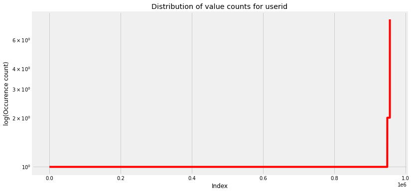

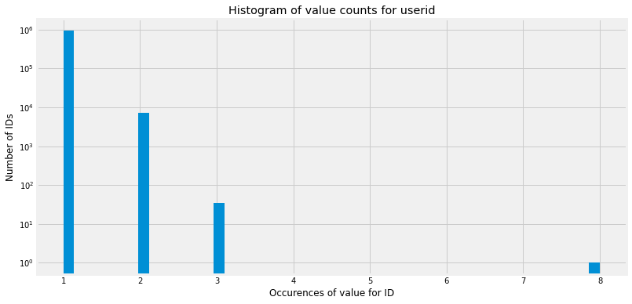

```
Variable 'userid': | Unique values: 956150 | Count of most common: 8 | Count of least common: 1 | count>10: 0.0% | count>100: 0.0% | count>1000: 0.0%
```

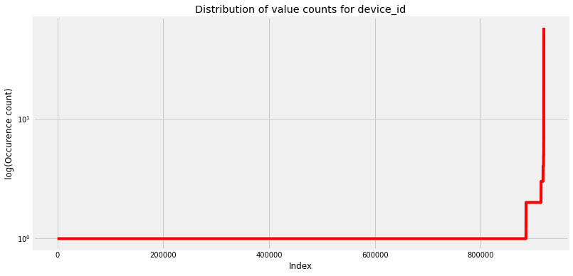

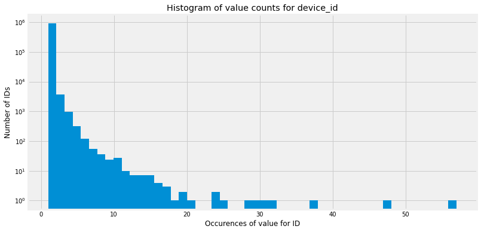

```
Variable 'device_id': | Unique values: 919495 | Count of most common: 57 | Count of least common: 1 | count>10: 0.01% | count>100: 0.0% | count>1000: 0.0%
```

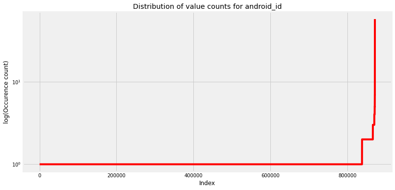

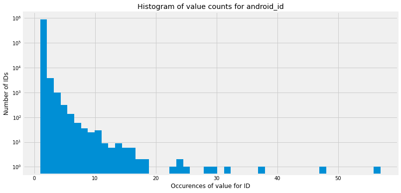

```
Variable 'android_id': | Unique values: 871760 | Count of most common: 57 | Count of least common: 1 | count>10: 0.01% | count>100: 0.0% | count>1000: 0.0%
```

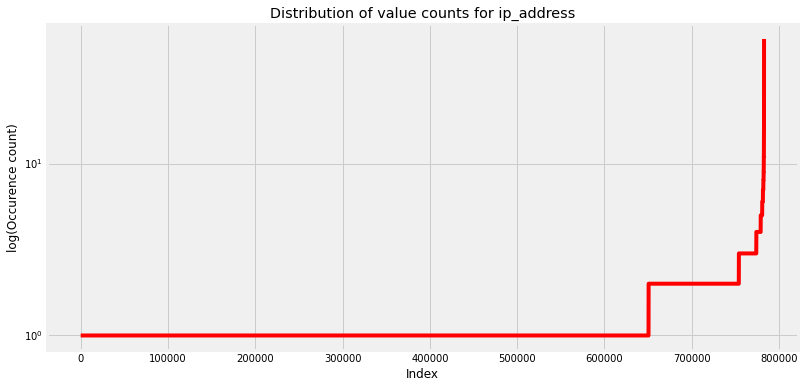

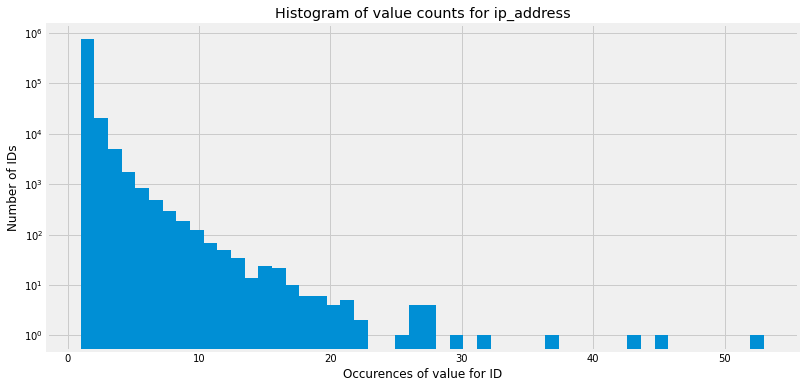

```
Variable 'ip_address': | Unique values: 782753 | Count of most common: 53 | Count of least common: 1 | count>10: 0.03% | count>100: 0.0% | count>1000: 0.0%
```

```python
for col, uniq in zip(cols, uniques):
    counts = user_df[col].value_counts()

    sorted_counts = np.sort(counts.values)
    fig = plt.figure(figsize=(12,6))
    ax = fig.add_subplot(1, 1, 1)
    line, = ax.plot(sorted_counts, color='red')
    ax.set_yscale('log')
    plt.title("Distribution of value counts for {}".format(col))
    plt.ylabel('log(Occurence count)')
    plt.xlabel('Index')
    plt.show()

    fig = plt.figure(figsize=(12,6))
    ax = fig.add_subplot(1, 1, 1)
    plt.hist(sorted_counts, bins=50)
    ax.set_yscale('log', nonposy='clip')
    plt.title("Histogram of value counts for {}".format(col))
    plt.ylabel('Number of IDs')
    plt.xlabel('Occurences of value for ID')
    plt.show()

    max_count = np.max(counts)
    min_count = np.min(counts)
    gt = [10, 100, 1000]
    prop_gt = []
    for value in gt:
        prop_gt.append(round((counts > value).mean()*100, 2))
    print("Variable '{}': | Unique values: {} | Count of most common: {} | Count of least common: {} | count>10: {}% | count>100: {}% | count>1000: {}%".format(col, uniq, max_count, min_count, *prop_gt))
```

#### IP Address vs Fraud Rates

```python
"""
Spot Trends of IP Address using Moving Average
"""
temp_df = user_df.groupby('ip_address').y.mean().to_frame().reset_index()

temp_df["ip_address"] = temp_df["ip_address"].astype('uint64')
temp_df["roll_y"] = temp_df["y"].rolling(window=1000).mean()

# fig = px.line(temp_df, x="ip_address", y="roll_y", title='Trends of IP Address vs Fraud Rates')
# fig.show()

# df = temp_df[(temp_df["ip_address"]> 4*10**18) & (temp_df["ip_address"]< 4.72*10**18)]

# fig = px.line(df, x="ip_address", y="roll_y", title='Trends of IP Address vs Fraud Rates')
# fig.show()

# df = temp_df[(temp_df["ip_address"]> 4.33*10**18) & (temp_df["ip_address"]< 4.37*10**18)]

# fig = px.line(df, x="ip_address", y="roll_y", title='Trends of IP Address vs Fraud Rates')
# fig.show()

df = temp_df[(temp_df["ip_address"]> 4.3364*10**18) & (temp_df["ip_address"]< 4.337*10**18)]

fig = px.line(df, x="ip_address", y="roll_y", title='Trends of IP Address vs Fraud Rates')
fig.show()
```

[interactive chart not shown]

**Key Takeaway:** Fraud rate is starts to climb at 4336411110523543628 IP Address

### Feature Engineering

#### Extracting Time Information

```python
## Convert event_timestamp into date time object
user_df['event_timestamp'] = pd.to_datetime(user_df['event_timestamp'])

## Extract relevant info
user_df['day'] = user_df['event_timestamp'].dt.day.astype('uint8')
user_df['hour'] = user_df['event_timestamp'].dt.hour.astype('uint8')
user_df['minute'] = user_df['event_timestamp'].dt.minute.astype('uint8')
user_df['second'] = user_df['event_timestamp'].dt.second.astype('uint8')
```

```python
"""
Hourly Registration Frequency & Hourly Conversion Ratio
"""
user_df['y'] = user_df['y'].astype('uint8')

temp_df = user_df[['hour','y']].groupby(['hour'], as_index=True).count().reset_index()

fig = px.line(temp_df, x="hour", y="y", title='Hourly Registration Frequency')
fig.show()

temp_df = user_df[['hour','y']].groupby(['hour'], as_index=True).mean().reset_index()
fig = px.line(temp_df, x="hour", y="y", title='Hourly Conversion Ratio')
fig.show()
```

[interactive chart not shown]

**Key Takeaway:** There is decreasing trend in # registration after `14th Hour` and conversion ratio is increasing from `19th to 21st Hour`

#### Group By - Aggregation Based Features

```python
"""
Let us first fill the null values which are available in device_id, android_id, ip_address
"""
user_df["device_id"] = user_df["device_id"].fillna("123456789")
user_df["android_id"] = user_df["android_id"].fillna("987654321")
user_df["ip_address"] = user_df["ip_address"].fillna("123456789987654321")
```

```python
"""
First Let us Define all the groupby aggregation transformations
"""
GROUPBY_AGGREGATIONS = [

    # V1 - Group by Features #
    ##########################
    # Variance in day, for ip_address-userid-device_id
    {'groupby': ['ip_address','userid','device_id'], 'select': 'day', 'agg': 'var'},
    # Variance in hour, for ip_address-userid-android_id
    {'groupby': ['ip_address','userid','android_id'], 'select': 'hour', 'agg': 'var'},
    # Variance in hour, for ip_address-day-device_id
    {'groupby': ['ip_address','day','device_id'], 'select': 'hour', 'agg': 'var'},
    # Count of device_id, for ip_address-day-hour
    {'groupby': ['ip_address','day','hour'], 'select': 'device_id', 'agg': 'count'},
    # Count of device_id, for ip_address-userid
    {'groupby': ['ip_address', 'userid'], 'select': 'device_id', 'agg': 'count'},
    # Count of device_id, for ip_address-userid-android_id
    {'groupby': ['ip_address', 'userid', 'android_id'], 'select': 'device_id', 'agg': 'count'},
    # Count of device_id, for ip_address-userid-day-hour
    {'groupby': ['ip_address','userid','day','hour'], 'select': 'device_id', 'agg': 'count'},
    # Mean hour, for ip_address-userid-device_id
    {'groupby': ['ip_address','userid','device_id'], 'select': 'hour', 'agg': 'mean'},

    # V2 - Group by Features #
    ##########################
    # Average registration on zomato app by distinct users
    {'groupby': ['userid'],
     'select': 'ip_address',
     'agg': lambda x: float(len(x)) / len(x.unique()),
     'agg_name': 'AvgViewPerDistinct'
    },
    # How popular is the userid for a device_id?
    {'groupby': ['userid'], 'select': 'device_id', 'agg': 'count'},
    {'groupby': ['device_id'], 'select': 'userid', 'agg': 'count'},

    # V3 - Group by Features (Unique/Count based) #
    ###############################################
    {'groupby': ['ip_address'], 'select': 'device_id', 'agg': 'nunique'},
    {'groupby': ['ip_address'], 'select': 'userid', 'agg': 'nunique'},
    {'groupby': ['ip_address','day'], 'select': 'hour', 'agg': 'nunique'},
    {'groupby': ['ip_address','userid'], 'select': 'android_id', 'agg': 'nunique'},
    {'groupby': ['userid'], 'select': 'device_id', 'agg': 'nunique'},
    {'groupby': ['ip_address', 'device_id', 'android_id'], 'select': 'userid', 'agg': 'nunique'},
    {'groupby': ['ip_address','device_id','android_id'], 'select': 'userid', 'agg': 'cumcount'},
    {'groupby': ['ip_address'], 'select': 'userid', 'agg': 'cumcount'},
    {'groupby': ['ip_address'], 'select': 'android_id', 'agg': 'cumcount'},
]

# Apply all the groupby transformations
for spec in GROUPBY_AGGREGATIONS:

    # Name of the aggregation we're applying
    agg_name = spec['agg_name'] if 'agg_name' in spec else spec['agg']

    # Name of new feature
    new_feature = '{}_{}_{}'.format('_'.join(spec['groupby']), agg_name, spec['select'])

    # Print statments
    print(">> Grouping by {}, and aggregating {} with {}".format(
        spec['groupby'], spec['select'], agg_name
    ))

    # Unique list of features to select
    all_features = list(set(spec['groupby'] + [spec['select']]))

    # Perform the groupby
    gp = user_df[all_features]. \
        groupby(spec['groupby'])[spec['select']]. \
        agg(spec['agg']). \
        reset_index(). \
        rename(index=str, columns={spec['select']: new_feature})

    # Merge back to original data
    if 'cumcount' == spec['agg']:
        user_df[new_feature] = gp[0].values
    else:
        user_df = user_df.merge(gp, on=spec['groupby'], how='left')

    # Clear memory
    del gp
    gc.collect()
```

```
>> Grouping by ['ip_address', 'userid', 'device_id'], and aggregating day with var
>> Grouping by ['ip_address', 'userid', 'android_id'], and aggregating hour with var
>> Grouping by ['ip_address', 'day', 'device_id'], and aggregating hour with var
>> Grouping by ['ip_address', 'day', 'hour'], and aggregating device_id with count
>> Grouping by ['ip_address', 'userid'], and aggregating device_id with count
>> Grouping by ['ip_address', 'userid', 'android_id'], and aggregating device_id with count
>> Grouping by ['ip_address', 'userid', 'day', 'hour'], and aggregating device_id with count
>> Grouping by ['ip_address', 'userid', 'device_id'], and aggregating hour with mean
>> Grouping by ['userid'], and aggregating ip_address with AvgViewPerDistinct
>> Grouping by ['userid'], and aggregating device_id with count
>> Grouping by ['device_id'], and aggregating userid with count
>> Grouping by ['ip_address'], and aggregating device_id with nunique
>> Grouping by ['ip_address'], and aggregating userid with nunique
>> Grouping by ['ip_address', 'day'], and aggregating hour with nunique
>> Grouping by ['ip_address', 'userid'], and aggregating android_id with nunique
>> Grouping by ['userid'], and aggregating device_id with nunique
>> Grouping by ['ip_address', 'device_id', 'android_id'], and aggregating userid with nunique
>> Grouping by ['ip_address', 'device_id', 'android_id'], and aggregating userid with cumcount
>> Grouping by ['ip_address'], and aggregating userid with cumcount
>> Grouping by ['ip_address'], and aggregating android_id with cumcount
```

#### Time Till Next Event Registration

How long it takes for a given ip_address-userid-device_id before they perform the next event registration?

```python
GROUP_BY_NEXT_EVENTS = [

    # V1
    {'groupby': ['ip_address']},
    {'groupby': ['ip_address', 'userid']},
    {'groupby': ['ip_address', 'device_id']},
    {'groupby': ['ip_address', 'android_id']},

    # V2
    {'groupby': ['ip_address', 'userid', 'android_id', 'device_id']},
    {'groupby': ['ip_address', 'android_id', 'device_id']},
]

# Calculate the time to next event for each group
for spec in GROUP_BY_NEXT_EVENTS:

    # Name of new feature
    new_feature = '{}_nextEvent'.format('_'.join(spec['groupby']))

    # Unique list of features to select
    all_features = spec['groupby'] + ['event_timestamp']

    # Run calculation
    print(f">> Grouping by {spec['groupby']}, and saving time to next event in: {new_feature}")
    user_df[new_feature] = user_df[all_features].groupby(spec['groupby']).event_timestamp.transform(lambda x: x.diff().shift(-1)).dt.seconds
```

```
>> Grouping by ['ip_address'], and saving time to next event in: ip_address_nextEvent
>> Grouping by ['ip_address', 'userid'], and saving time to next event in: ip_address_userid_nextEvent
>> Grouping by ['ip_address', 'device_id'], and saving time to next event in: ip_address_device_id_nextEvent
>> Grouping by ['ip_address', 'android_id'], and saving time to next event in: ip_address_android_id_nextEvent
>> Grouping by ['ip_address', 'userid', 'android_id', 'device_id'], and saving time to next event in: ip_address_userid_android_id_device_id_nextEvent
>> Grouping by ['ip_address', 'android_id', 'device_id'], and saving time to next event in: ip_address_android_id_device_id_nextEvent
```

#### Device Registrations Before & After

Has the user previously or subsequently registered the exact same device?

```python
HISTORY_EVENTS = {
    'identical_events': ['ip_address', 'userid', 'device_id', 'android_id'],
    'app_events': ['ip_address', 'userid']
}

# Go through different group-by combinations
for fname, fset in HISTORY_EVENTS.items():

    # Registration in the past
    user_df['prev_'+fname] = user_df. \
        groupby(fset). \
        cumcount(). \
        rename('prev_'+fname)

    # Registration in the future
    user_df['future_'+fname] = user_df.iloc[::-1]. \
        groupby(fset). \
        cumcount(). \
        rename('future_'+fname).iloc[::-1]
```

#### Save All Features

```python
pickle.dump(user_df, open(os.path.join(PROCESSED_DIR,"user_all_features.pkl"), "wb"))
```

```python
user_df = pickle.load(open(os.path.join(PROCESSED_DIR,"user_all_features.pkl"), 'rb'))
```

### Modeling Data Preparation

```python
"""
Let's remove irrelevant columns
"""
model_df = user_df.drop(['event_timestamp', 'userid', 'android_id', 'device_id', 'ip_address'], axis = 1)
```

```python
pickle.dump(model_df, open(os.path.join(CLEANED_DIR,"user_model_features.pkl"), "wb"))
```

```python
model_df = pickle.load(open(os.path.join(CLEANED_DIR,"user_model_features.pkl"), 'rb'))
```

### Predictive Modeling Pipeline - Pycaret

#### Baseline Model

```python
"""
Lets build the model using only given features: 'userid', 'device_id', 'android_id','ip_address'
"""
from pycaret.classification import *
baseline_df = user_df[['userid', 'device_id', 'android_id','ip_address', 'y']]
baseline_clf = setup(baseline_df,
                   target = 'y',
                   session_id=345,
                   experiment_name='baseline_fraud_detection')
```

|  | Description | Value |
| --- | --- | --- |
| 0 | session_id | 345 |
| 1 | Target | y |
| 2 | Target Type | Binary |
| 3 | Label Encoded | None |
| 4 | Original Data | (963535, 5) |
| 5 | Missing Values | False |
| 6 | Numeric Features | 4 |
| 7 | Categorical Features | 0 |
| 8 | Ordinal Features | False |
| 9 | High Cardinality Features | False |
| 10 | High Cardinality Method | None |
| 11 | Transformed Train Set | (674474, 4) |
| 12 | Transformed Test Set | (289061, 4) |
| 13 | Shuffle Train-Test | True |
| 14 | Stratify Train-Test | False |
| 15 | Fold Generator | StratifiedKFold |
| 16 | Fold Number | 10 |
| 17 | CPU Jobs | -1 |
| 18 | Use GPU | False |
| 19 | Log Experiment | False |
| 20 | Experiment Name | baseline_fraud_detection |
| 21 | USI | 26da |
| 22 | Imputation Type | simple |
| 23 | Iterative Imputation Iteration | None |
| 24 | Numeric Imputer | mean |
| 25 | Iterative Imputation Numeric Model | None |
| 26 | Categorical Imputer | constant |
| 27 | Iterative Imputation Categorical Model | None |
| 28 | Unknown Categoricals Handling | least_frequent |
| 29 | Normalize | False |
| 30 | Normalize Method | None |
| 31 | Transformation | False |
| 32 | Transformation Method | None |
| 33 | PCA | False |
| 34 | PCA Method | None |
| 35 | PCA Components | None |
| 36 | Ignore Low Variance | False |
| 37 | Combine Rare Levels | False |
| 38 | Rare Level Threshold | None |
| 39 | Numeric Binning | False |
| 40 | Remove Outliers | False |
| 41 | Outliers Threshold | None |
| 42 | Remove Multicollinearity | False |
| 43 | Multicollinearity Threshold | None |
| 44 | Clustering | False |
| 45 | Clustering Iteration | None |
| 46 | Polynomial Features | False |
| 47 | Polynomial Degree | None |
| 48 | Trignometry Features | False |
| 49 | Polynomial Threshold | None |
| 50 | Group Features | False |
| 51 | Feature Selection | False |
| 52 | Features Selection Threshold | None |
| 53 | Feature Interaction | False |
| 54 | Feature Ratio | False |
| 55 | Interaction Threshold | None |
| 56 | Fix Imbalance | False |
| 57 | Fix Imbalance Method | SMOTE |

```python
lightgbm_baseline_model = create_model('lightgbm')
```

|  | Accuracy | AUC | Recall | Prec. | F1 | Kappa | MCC |
| --- | --- | --- | --- | --- | --- | --- | --- |
| 0 | 0.9668 | 0.5481 | 0.0000 | 0.0000 | 0.0000 | 0.0000 | 0.0000 |
| 1 | 0.9668 | 0.5460 | 0.0000 | 0.0000 | 0.0000 | 0.0000 | 0.0000 |
| 2 | 0.9668 | 0.5493 | 0.0004 | 0.5000 | 0.0009 | 0.0008 | 0.0142 |
| 3 | 0.9668 | 0.5483 | 0.0000 | 0.0000 | 0.0000 | -0.0000 | -0.0007 |
| 4 | 0.9668 | 0.5491 | 0.0000 | 0.0000 | 0.0000 | 0.0000 | 0.0000 |
| 5 | 0.9668 | 0.5479 | 0.0000 | 0.0000 | 0.0000 | 0.0000 | 0.0000 |
| 6 | 0.9668 | 0.5405 | 0.0000 | 0.0000 | 0.0000 | -0.0000 | -0.0007 |
| 7 | 0.9668 | 0.5504 | 0.0000 | 0.0000 | 0.0000 | 0.0000 | 0.0000 |
| 8 | 0.9668 | 0.5487 | 0.0000 | 0.0000 | 0.0000 | 0.0000 | 0.0000 |
| 9 | 0.9668 | 0.5393 | 0.0009 | 1.0000 | 0.0018 | 0.0017 | 0.0294 |
| Mean | 0.9668 | 0.5468 | 0.0001 | 0.1500 | 0.0003 | 0.0002 | 0.0042 |
| SD | 0.0000 | 0.0036 | 0.0003 | 0.3202 | 0.0006 | 0.0006 | 0.0094 |

**Key Takeaway:** From above results, we can say that baseline model `(AUC=0.55)` is performing almost similar to random classifier `(AUC=0.5)`

#### Model After Feature Engineering

```python
"""
Let us build the model after including additional features
"""
from pycaret.classification import *
pycaret_clf = setup(model_df,
                   target = 'y',
                   session_id=123,
                   experiment_name='fraud_detection')
```

|  | Description | Value |
| --- | --- | --- |
| 0 | session_id | 123 |
| 1 | Target | y |
| 2 | Target Type | Binary |
| 3 | Label Encoded | None |
| 4 | Original Data | (963535, 36) |
| 5 | Missing Values | True |
| 6 | Numeric Features | 22 |
| 7 | Categorical Features | 13 |
| 8 | Ordinal Features | False |
| 9 | High Cardinality Features | False |
| 10 | High Cardinality Method | None |
| 11 | Transformed Train Set | (674474, 85) |
| 12 | Transformed Test Set | (289061, 85) |
| 13 | Shuffle Train-Test | True |
| 14 | Stratify Train-Test | False |
| 15 | Fold Generator | StratifiedKFold |
| 16 | Fold Number | 10 |
| 17 | CPU Jobs | -1 |
| 18 | Use GPU | False |
| 19 | Log Experiment | False |
| 20 | Experiment Name | fraud_detection |
| 21 | USI | 02a5 |
| 22 | Imputation Type | simple |
| 23 | Iterative Imputation Iteration | None |
| 24 | Numeric Imputer | mean |
| 25 | Iterative Imputation Numeric Model | None |
| 26 | Categorical Imputer | constant |
| 27 | Iterative Imputation Categorical Model | None |
| 28 | Unknown Categoricals Handling | least_frequent |
| 29 | Normalize | False |
| 30 | Normalize Method | None |
| 31 | Transformation | False |
| 32 | Transformation Method | None |
| 33 | PCA | False |
| 34 | PCA Method | None |
| 35 | PCA Components | None |
| 36 | Ignore Low Variance | False |
| 37 | Combine Rare Levels | False |
| 38 | Rare Level Threshold | None |
| 39 | Numeric Binning | False |
| 40 | Remove Outliers | False |
| 41 | Outliers Threshold | None |
| 42 | Remove Multicollinearity | False |
| 43 | Multicollinearity Threshold | None |
| 44 | Clustering | False |
| 45 | Clustering Iteration | None |
| 46 | Polynomial Features | False |
| 47 | Polynomial Degree | None |
| 48 | Trignometry Features | False |
| 49 | Polynomial Threshold | None |
| 50 | Group Features | False |
| 51 | Feature Selection | False |
| 52 | Features Selection Threshold | None |
| 53 | Feature Interaction | False |
| 54 | Feature Ratio | False |
| 55 | Interaction Threshold | None |
| 56 | Fix Imbalance | False |
| 57 | Fix Imbalance Method | SMOTE |

#### Create Model

```python
lightgbm_model = create_model('lightgbm')
```

|  | Accuracy | AUC | Recall | Prec. | F1 | Kappa | MCC |
| --- | --- | --- | --- | --- | --- | --- | --- |
| 0 | 0.9726 | 0.8489 | 0.2954 | 0.7092 | 0.4170 | 0.4054 | 0.4468 |
| 1 | 0.9726 | 0.8485 | 0.3226 | 0.6857 | 0.4388 | 0.4266 | 0.4588 |
| 2 | 0.9724 | 0.8467 | 0.2805 | 0.7161 | 0.4031 | 0.3917 | 0.4375 |
| 3 | 0.9729 | 0.8530 | 0.3077 | 0.7147 | 0.4302 | 0.4186 | 0.4581 |
| 4 | 0.9723 | 0.8459 | 0.3070 | 0.6822 | 0.4234 | 0.4113 | 0.4461 |
| 5 | 0.9727 | 0.8509 | 0.2945 | 0.7155 | 0.4172 | 0.4057 | 0.4482 |
| 6 | 0.9728 | 0.8594 | 0.3101 | 0.7053 | 0.4308 | 0.4190 | 0.4566 |
| 7 | 0.9732 | 0.8579 | 0.3159 | 0.7170 | 0.4386 | 0.4270 | 0.4650 |
| 8 | 0.9729 | 0.8615 | 0.2958 | 0.7251 | 0.4202 | 0.4088 | 0.4525 |
| 9 | 0.9733 | 0.8581 | 0.3226 | 0.7170 | 0.4450 | 0.4333 | 0.4700 |
| Mean | 0.9728 | 0.8531 | 0.3052 | 0.7088 | 0.4264 | 0.4147 | 0.4540 |
| SD | 0.0003 | 0.0054 | 0.0129 | 0.0134 | 0.0120 | 0.0119 | 0.0092 |

#### Tune Model

```python
tuned_lightbm = tune_model(lightgbm_model)
```

|  | Accuracy | AUC | Recall | Prec. | F1 | Kappa | MCC |
| --- | --- | --- | --- | --- | --- | --- | --- |
| 0 | 0.9725 | 0.8502 | 0.2913 | 0.7079 | 0.4128 | 0.4012 | 0.4433 |
| 1 | 0.9724 | 0.8502 | 0.3141 | 0.6845 | 0.4306 | 0.4185 | 0.4522 |
| 2 | 0.9721 | 0.8458 | 0.2858 | 0.6926 | 0.4047 | 0.3929 | 0.4338 |
| 3 | 0.9730 | 0.8526 | 0.3202 | 0.7078 | 0.4410 | 0.4292 | 0.4650 |
| 4 | 0.9720 | 0.8475 | 0.2936 | 0.6822 | 0.4105 | 0.3985 | 0.4361 |
| 5 | 0.9723 | 0.8495 | 0.2940 | 0.6970 | 0.4136 | 0.4018 | 0.4416 |
| 6 | 0.9725 | 0.8617 | 0.3065 | 0.6929 | 0.4250 | 0.4131 | 0.4496 |
| 7 | 0.9731 | 0.8588 | 0.3092 | 0.7231 | 0.4332 | 0.4217 | 0.4621 |
| 8 | 0.9730 | 0.8607 | 0.2954 | 0.7280 | 0.4202 | 0.4089 | 0.4531 |
| 9 | 0.9730 | 0.8562 | 0.3146 | 0.7082 | 0.4356 | 0.4239 | 0.4610 |
| Mean | 0.9726 | 0.8533 | 0.3025 | 0.7024 | 0.4227 | 0.4110 | 0.4498 |
| SD | 0.0004 | 0.0054 | 0.0112 | 0.0145 | 0.0116 | 0.0116 | 0.0104 |

#### Analyze Model

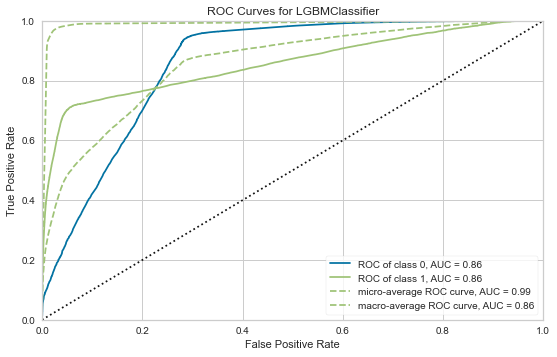

```python
plot_model(lightgbm_model)
```

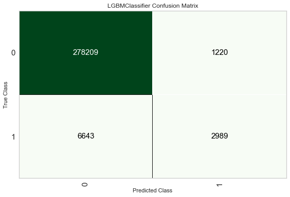

```python
plot_model(lightgbm_model, plot = 'confusion_matrix')
```

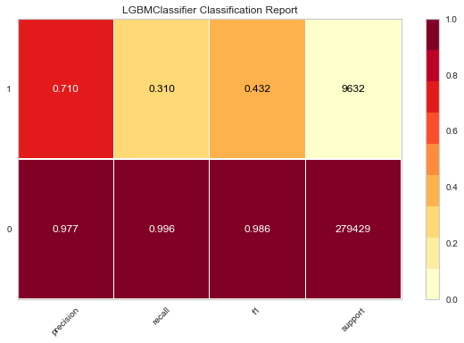

```python
plot_model(lightgbm_model, plot = 'class_report')
```

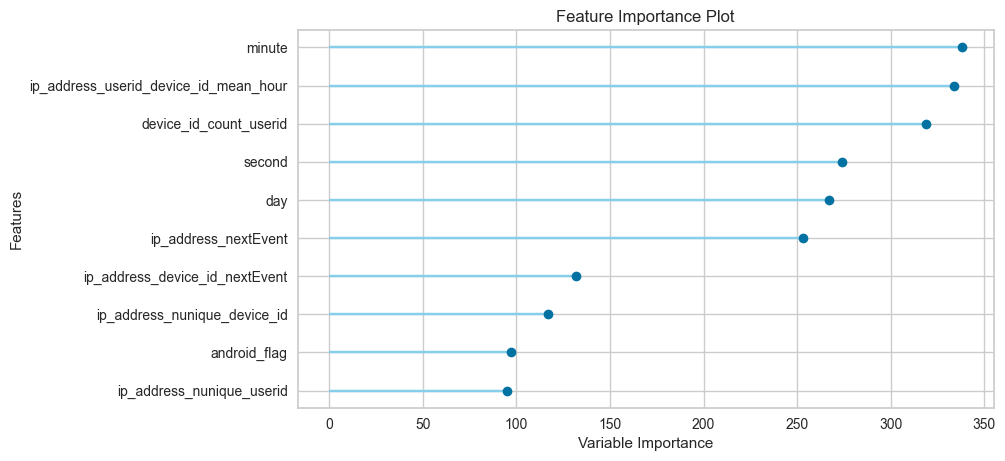

```python
plot_model(lightgbm_model, plot = 'feature')
```

**Key Takeaway:** Groupby Aggregation based features, android_flag, time features are coming out most important features

#### Intrepret Model

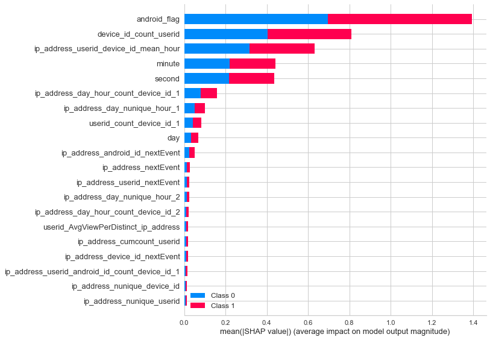

```python
interpret_model(lightgbm_model)
```

```python
"""
a) The Red bar shows how much the probability that the target is 1 (Fraud) is increased
b) The Blue bars show that these variables decrease the probability of Fraud
"""
interpret_model(lightgbm_model, plot = 'reason', observation = 8)
```

#### Fix Imbalance using SMOTE

```python
"""
Let us build model using oversample technique (SMOTE: Synthetic Minority Oversampling Technique)

SMOTE -

SMOTE first selects a minority class instance a at random and finds its k nearest minority class neighbors. The synthetic
instance is then created by choosing one of the k nearest neighbors b at random and connecting a and b to form a line segment
in the feature space. The synthetic instances are generated as a convex combination (linear combination of points) of the two
chosen instances a and b.
"""
from pycaret.classification import *
smote_pycaret_clf = setup(model_df,
                   target = 'y',
                   session_id=567,
                   experiment_name='smote_fraud_detection',
                   fix_imbalance=True)
```

|  | Description | Value |
| --- | --- | --- |
| 0 | session_id | 567 |
| 1 | Target | y |
| 2 | Target Type | Binary |
| 3 | Label Encoded | None |
| 4 | Original Data | (963535, 36) |
| 5 | Missing Values | True |
| 6 | Numeric Features | 22 |
| 7 | Categorical Features | 13 |
| 8 | Ordinal Features | False |
| 9 | High Cardinality Features | False |
| 10 | High Cardinality Method | None |
| 11 | Transformed Train Set | (674474, 85) |
| 12 | Transformed Test Set | (289061, 85) |
| 13 | Shuffle Train-Test | True |
| 14 | Stratify Train-Test | False |
| 15 | Fold Generator | StratifiedKFold |
| 16 | Fold Number | 10 |
| 17 | CPU Jobs | -1 |
| 18 | Use GPU | False |
| 19 | Log Experiment | False |
| 20 | Experiment Name | smote_fraud_detection |
| 21 | USI | 8f13 |
| 22 | Imputation Type | simple |
| 23 | Iterative Imputation Iteration | None |
| 24 | Numeric Imputer | mean |
| 25 | Iterative Imputation Numeric Model | None |
| 26 | Categorical Imputer | constant |
| 27 | Iterative Imputation Categorical Model | None |
| 28 | Unknown Categoricals Handling | least_frequent |
| 29 | Normalize | False |
| 30 | Normalize Method | None |
| 31 | Transformation | False |
| 32 | Transformation Method | None |
| 33 | PCA | False |
| 34 | PCA Method | None |
| 35 | PCA Components | None |
| 36 | Ignore Low Variance | False |
| 37 | Combine Rare Levels | False |
| 38 | Rare Level Threshold | None |
| 39 | Numeric Binning | False |
| 40 | Remove Outliers | False |
| 41 | Outliers Threshold | None |
| 42 | Remove Multicollinearity | False |
| 43 | Multicollinearity Threshold | None |
| 44 | Clustering | False |
| 45 | Clustering Iteration | None |
| 46 | Polynomial Features | False |
| 47 | Polynomial Degree | None |
| 48 | Trignometry Features | False |
| 49 | Polynomial Threshold | None |
| 50 | Group Features | False |
| 51 | Feature Selection | False |
| 52 | Features Selection Threshold | None |
| 53 | Feature Interaction | False |
| 54 | Feature Ratio | False |
| 55 | Interaction Threshold | None |
| 56 | Fix Imbalance | True |
| 57 | Fix Imbalance Method | SMOTE |

```python
lightgbm_smote_model = create_model('lightgbm')
```

|  | Accuracy | AUC | Recall | Prec. | F1 | Kappa | MCC |
| --- | --- | --- | --- | --- | --- | --- | --- |
| 0 | 0.9697 | 0.8473 | 0.4147 | 0.5624 | 0.4774 | 0.4621 | 0.4678 |
| 1 | 0.9690 | 0.8411 | 0.4262 | 0.5458 | 0.4787 | 0.4630 | 0.4667 |
| 2 | 0.9678 | 0.8420 | 0.4200 | 0.5224 | 0.4656 | 0.4493 | 0.4521 |
| 3 | 0.9684 | 0.8387 | 0.4178 | 0.5338 | 0.4687 | 0.4527 | 0.4563 |
| 4 | 0.9686 | 0.8475 | 0.4273 | 0.5366 | 0.4757 | 0.4598 | 0.4629 |
| 5 | 0.9691 | 0.8408 | 0.4055 | 0.5504 | 0.4670 | 0.4515 | 0.4570 |
| 6 | 0.9695 | 0.8503 | 0.4211 | 0.5567 | 0.4795 | 0.4641 | 0.4689 |
| 7 | 0.9698 | 0.8451 | 0.4233 | 0.5623 | 0.4830 | 0.4678 | 0.4728 |
| 8 | 0.9685 | 0.8341 | 0.4364 | 0.5346 | 0.4805 | 0.4645 | 0.4670 |
| 9 | 0.9700 | 0.8612 | 0.4467 | 0.5637 | 0.4984 | 0.4831 | 0.4866 |
| Mean | 0.9691 | 0.8448 | 0.4239 | 0.5469 | 0.4775 | 0.4618 | 0.4658 |
| SD | 0.0007 | 0.0071 | 0.0108 | 0.0138 | 0.0090 | 0.0093 | 0.0093 |